# Putting It All Together: Advanced Plotting

ASI: Introduction to R

Author

Affiliation

Dr Stevie Pederson

Black Ochre Data Labs  
Telethon Kids Institute

Published

November 22, 2023

# Using the Tidyverse Together

## Using the Tidyverse

We’ve already learned a huge amount:

1. Importing Data using `readr`
2. Making plots with `ggplot2`
3. Working with vectors & categorical variables (factors)
4. Logical tests
5. Using `dplyr` with spreadsheet-like data
6. Joining functions together with `|>`
- Next we’ll:
- Use everything to make more detailed figures
- Perform a few analyses
- Utilise some features of `tidyr`

## Section Setup

1. Clear your `R` Environment
2. Start a new `R` script: `AdvancedPlotting.R`
3. Load the `tidyverse`
4. Define a default `ggplot2` theme
5. Import Transport as previously

```r
library(tidyverse)
theme_set(theme_bw())
cols <- c(
  "gender", "name", "weight", "height", "method"
)
transport <- "data/transport.csv" |>
  read_csv(
    comment = "#",
    col_names = cols,
    col_types = "-ccnnc"
  ) |>
  mutate(
    gender = case_when(
      gender == "F" ~ "female",
      gender == "M" ~ "male",
      TRUE ~ str_to_lower(gender)
    ),
    gender = as.factor(gender),
    method = factor(
      method,
      levels = c("car", "bike")
    ),
    BMI = weight / (0.01 * height) ^ 2
  )
```

## Section Outline

- Using the pipe to create plots
- Customising plots in detail
- Reshaping data using `tidyr`

# Visualising Data

## Visualising Our Data

- What might we like to show?
- Relationship between weight & height?
- Association with transportation method
- Distributions of BMI?

## A Simple X-Y Plot

- When plotting, we can simply pipe the data into `ggplot`

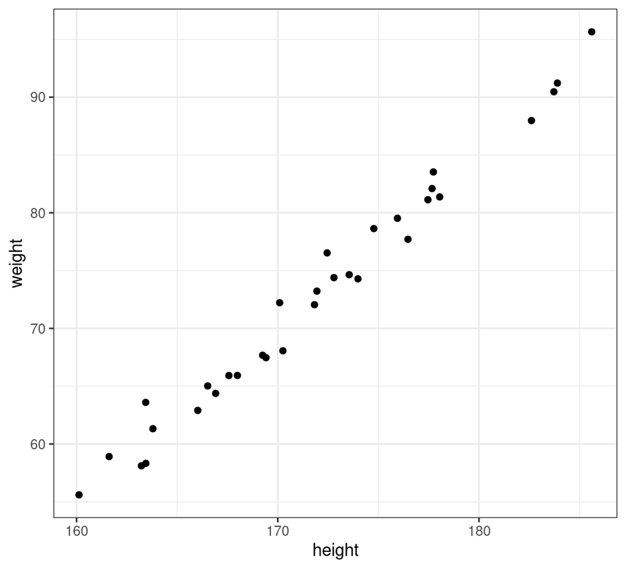

```r
transport |>
  ggplot(aes(height, weight)) +
  geom_point()
```

## Adding Lines of Best Fit

- Sometimes a regression line can be informative
- `geom_smooth()` guesses the best line

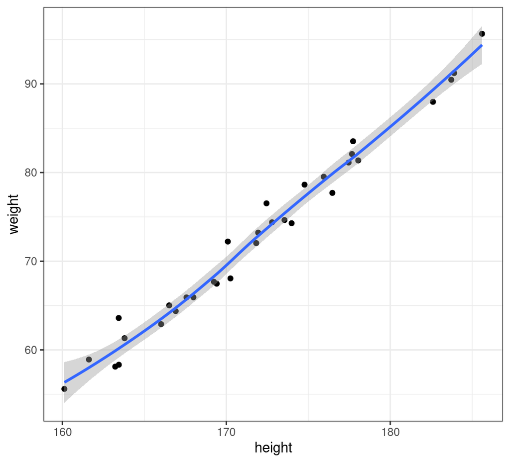

```r
transport |>
  ggplot(aes(height, weight)) +
  geom_point() +
  geom_smooth()
```

## Adding Regresion Lines

- We can choose a linear regression line: `method = "lm"`
- Fits linear regression in `R` using the function `lm()`
- Hide the standard error of the regression line: `se = FALSE`

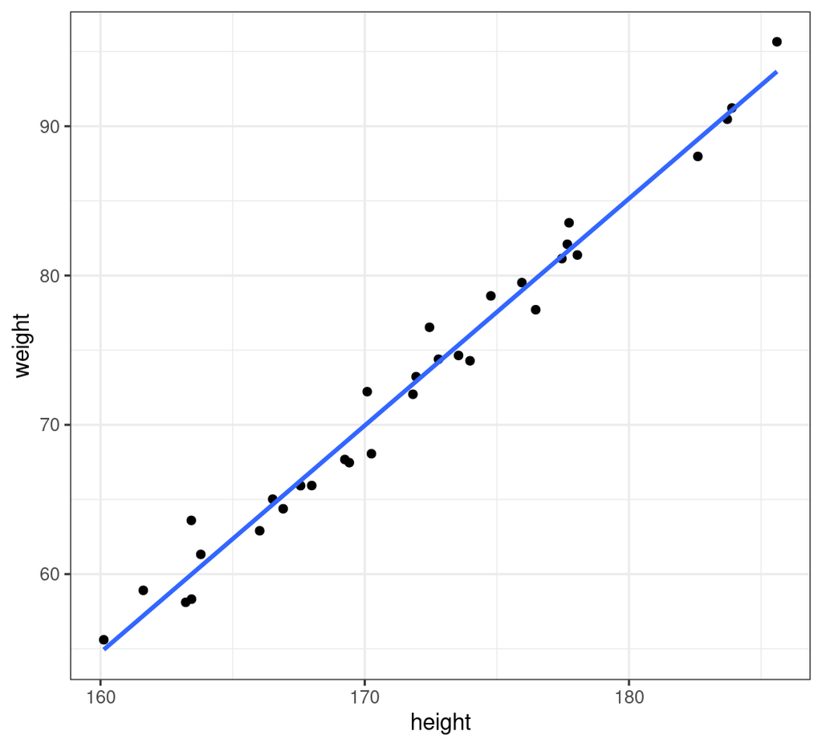

```r
transport |>
  ggplot(aes(height, weight)) +
  geom_point() +
  geom_smooth(method = "lm", se =  FALSE)
```

## Customising Parameters

- We can change the colour of the line: `colour = "black"`
- Anything set inside `aes()` should be a column in your data
- Anything set outside of `aes()` is a fixed-value $\implies$ over-rides `aes()`
- Can also set `linetype`, `linewidth`, `alpha` etc
- Is `geom_*` specific

## Customising Parameters

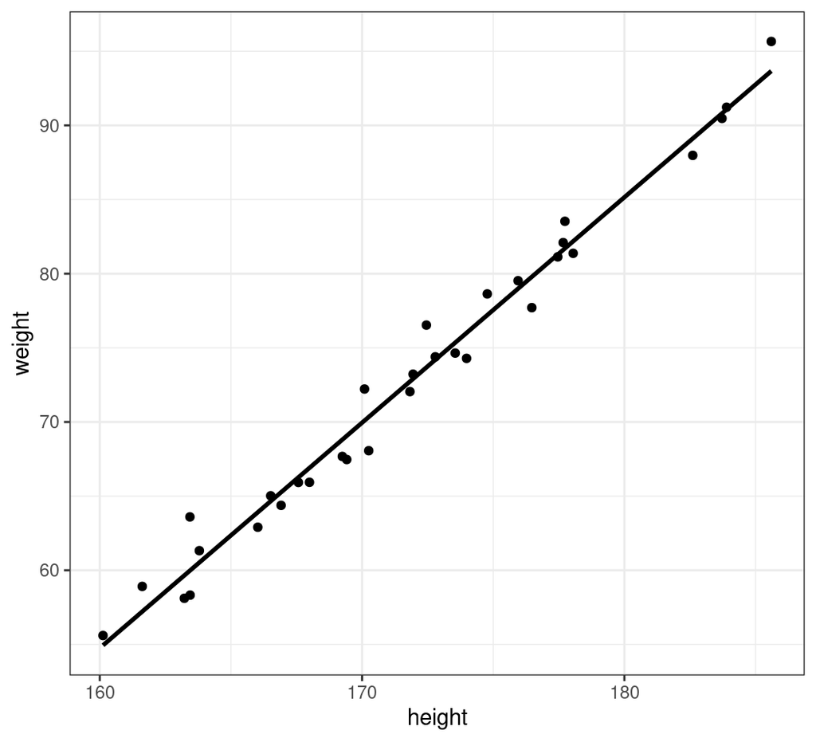

```r
transport |>
  ggplot(aes(height, weight)) +
  geom_point() +
  geom_smooth(
    method = "lm", se =  FALSE, colour = "black"
  )
```

## Changing Shapes

- Similarly for the points: `colour = "red"`
- The range of shapes is visible using `?pch`
- Additional parameters include `size`, `alpha`

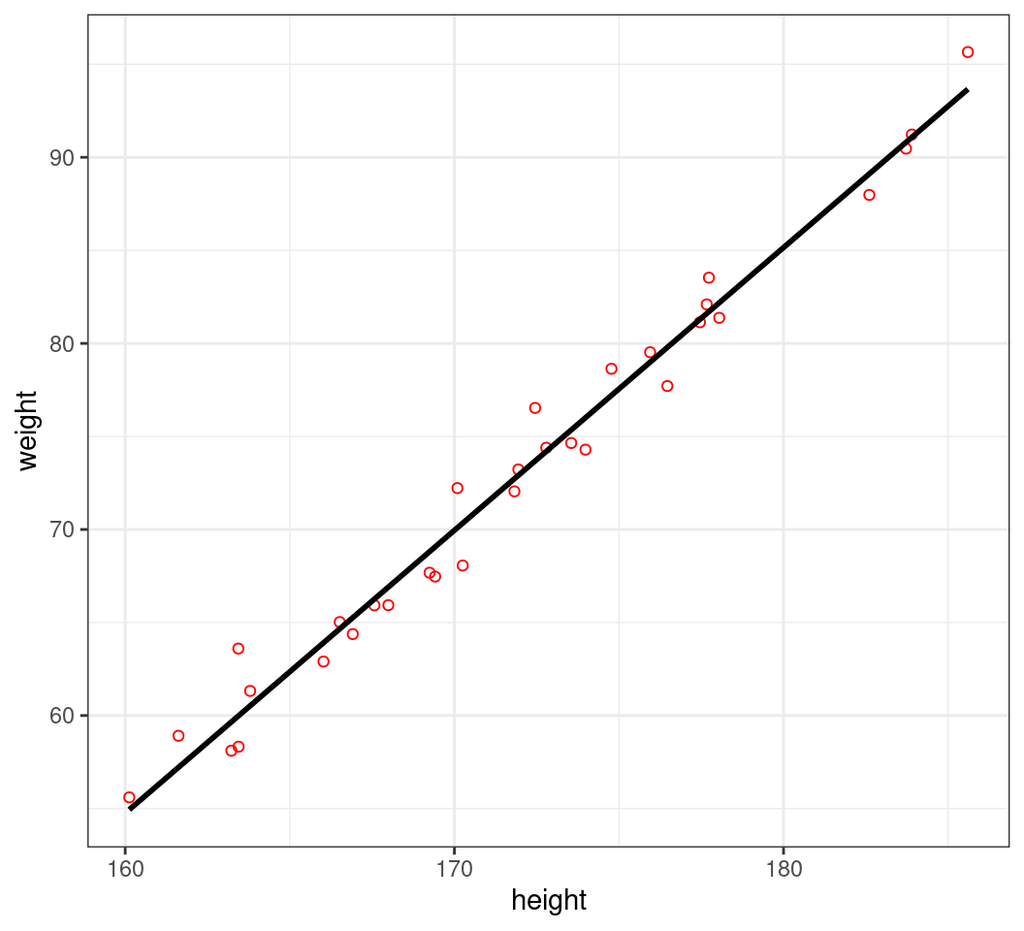

```r
transport |>
  ggplot(aes(height, weight)) +
  geom_point(colour = "red", shape = 1) +
  geom_smooth(
    method = "lm", se =  FALSE, colour = "black"
  )
```

For shapes 21-25 colour is outline, fill is the internal colour

## Parameters Inside or Outside `aes()`

- Parameters set outside `aes()` will over-ride anything inside `aes()`
- We have globally set colour to depend on `gender`
- This is overridden by both `geom_point()` and `geom_smooth()`

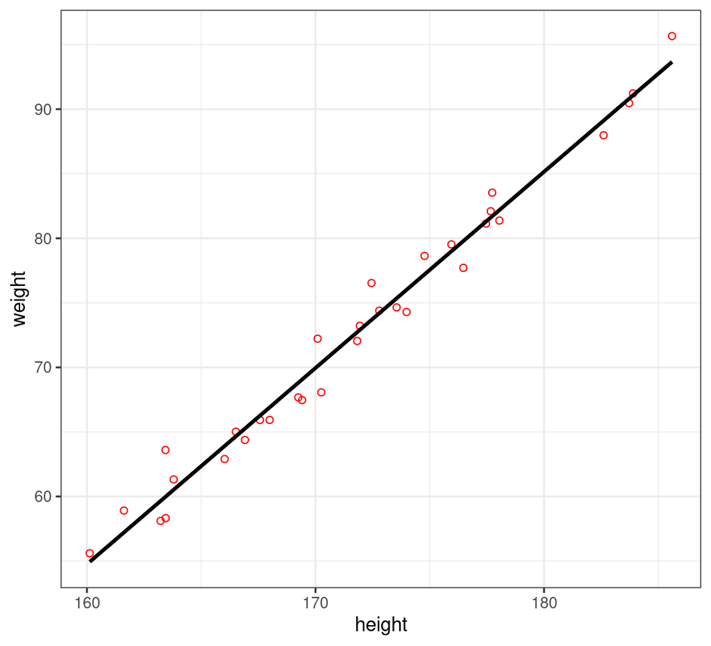

```r
transport |>
  ggplot(
    aes(height, weight, colour = gender)
  ) +
  geom_point(colour = "red", shape = 1) +
  geom_smooth(
    method = "lm", se =  FALSE, colour = "black"
  )
```

## Parameters Inside or Outside `aes()`

- Now remove the colour from `geom_point()`
- Inherits from the `aes()` within `ggplot()`

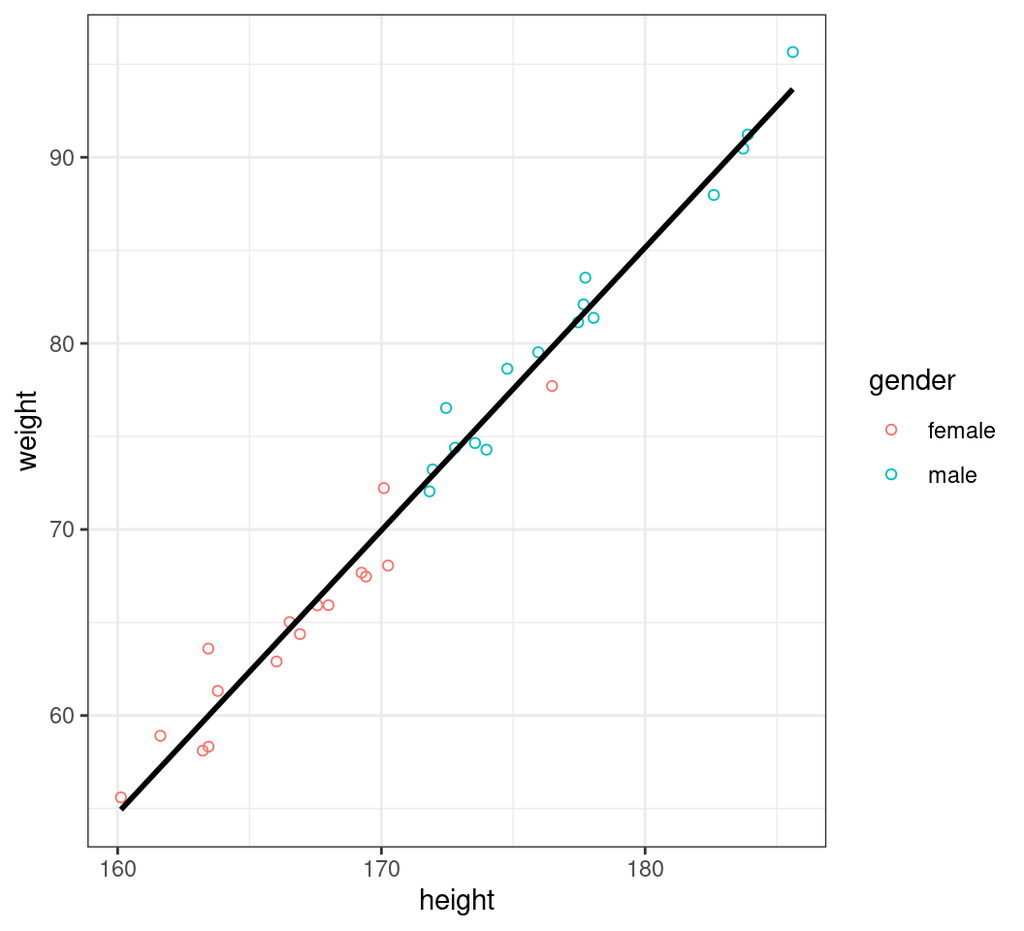

```r
transport |>
  ggplot(
    aes(height, weight, colour = gender)
  ) +
  geom_point(shape = 1) +
  geom_smooth(
    method = "lm", se =  FALSE, colour = "black"
  )
```

## Custom Scales

- Providing specific colours can take a vector
- Can be named for greater control

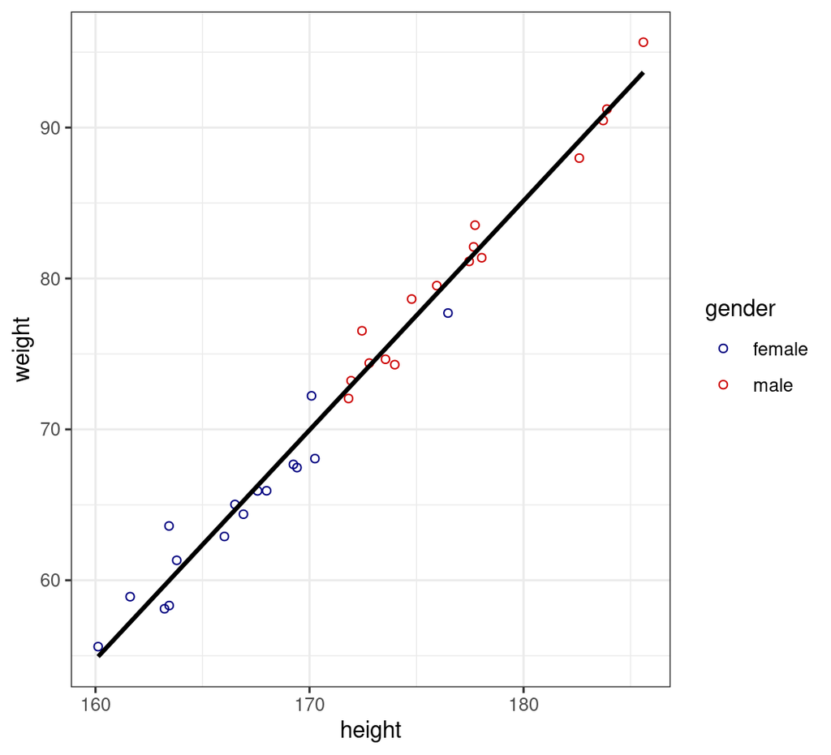

```r
transport |>
  ggplot(
    aes(height, weight, colour = gender)
  ) +
  geom_point(shape = 1) +
  geom_smooth(
    method = "lm", se =  FALSE, colour = "black"
  ) +
  scale_colour_manual(
    values = c(
      female = "navyblue", male = "red3"
    )
  )
```

## Custom Scales

- Likewise for shapes
- Values are applied in the same order as the legend

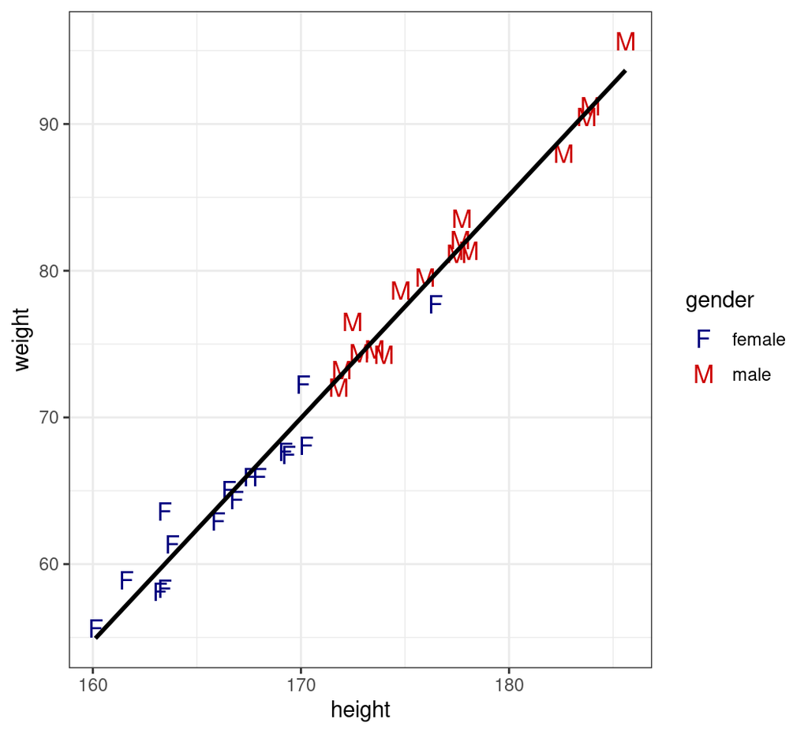

```r
transport |>
  ggplot(
    aes(height, weight, colour = gender)
  ) +
  geom_point(
    aes(shape = gender), size = 4
  ) +
  geom_smooth(
    method = "lm", se =  FALSE, colour = "black"
  ) +
  scale_colour_manual(
    values = c(
      female = "navyblue", male = "red3"
    )
  ) +
  scale_shape_manual(values = c("F", "M"))
```

## Adding Statistics

- Sometimes we might wish to add summary statistics to plots
- We can create on the fly *inside a geom_*

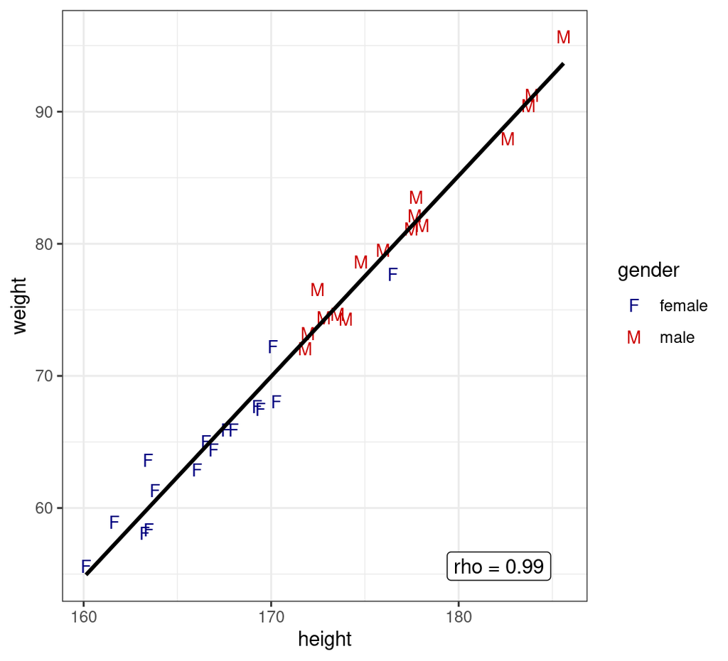

```r
transport |>
  ggplot(aes(height, weight)) +
  geom_point(
    aes(colour = gender, shape = gender),
    size = 3
  ) +
  geom_smooth(
    method = "lm", se =  FALSE, colour = "black"
  ) +
  geom_label(
    aes(label = label),
    data = . %>% ## Only the magrittr works here
      summarise(
        cor = cor(weight, height),
        height = quantile(height, 0.9),
        weight = min(weight),
      )  %>%
      mutate(label = paste("rho =", round(cor, 2)))
  ) +
  scale_colour_manual(
    values = c(female = "navyblue", male = "red3")
  ) +
  scale_shape_manual(values = c("F", "M"))
```

## Using Additional Packages

- There are multiple options for adding other labels

. . .

- Add this to the top of your script  
  $\implies$ Make sure the package is loaded

```r
library(ggpmisc)
```

## Using Additional Packages

- `stat_poly_eq()` can add $R^2$, adjusted $R^2$ or regression equations

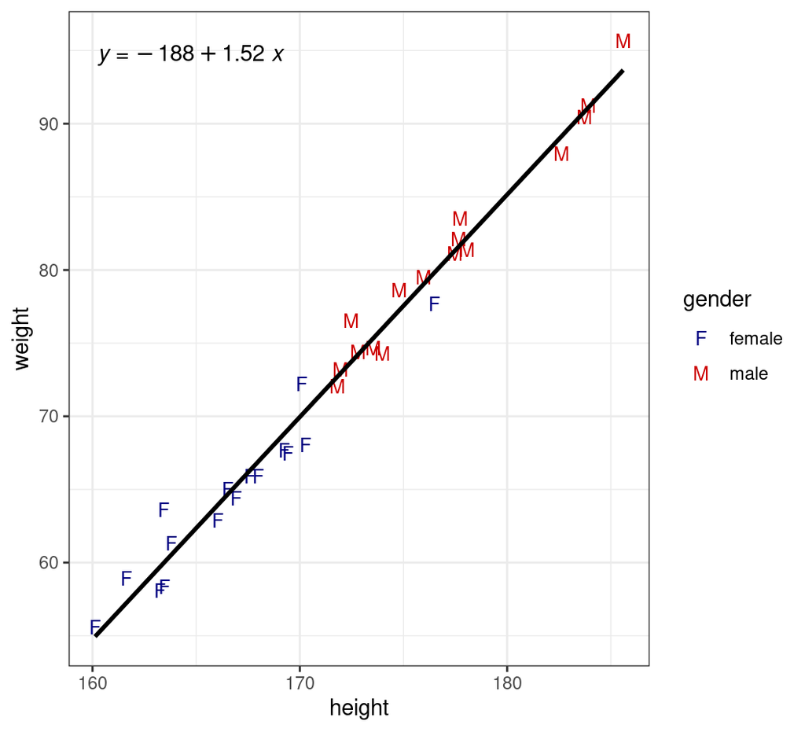

```r
transport |>
  ggplot(aes(height, weight)) +
  geom_point(
    aes(colour = gender, shape = gender),
    size = 3
  ) +
  geom_smooth(
    method = "lm", se =  FALSE, colour = "black"
  ) +
  stat_poly_eq(use_label("eq")) +
  scale_colour_manual(
    values = c(
      female = "navyblue", male = "red3"
    )
  ) +
  scale_shape_manual(values = c("F", "M"))
```

## Multiple Regression Equations

- Combining with facets can provide multiple equations

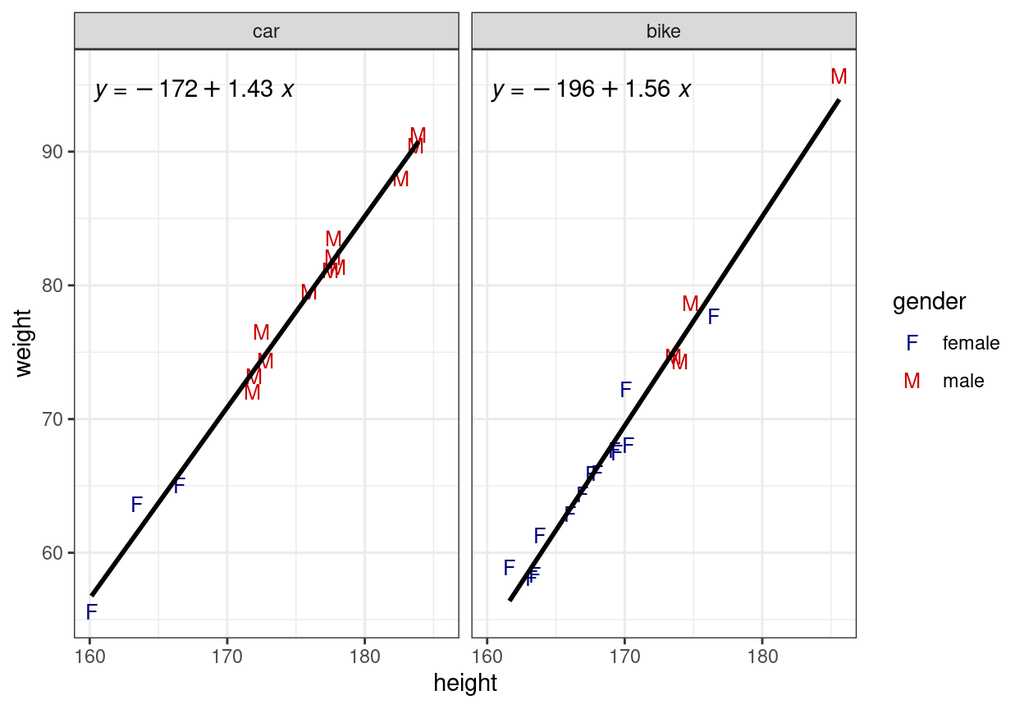

```r
transport |>
  ggplot(aes(height, weight)) +
  geom_point(
    aes(colour = gender, shape = gender),
    size = 3
  ) +
  geom_smooth(
    method = "lm", se =  FALSE, colour = "black"
  ) +
  stat_poly_eq(use_label("eq")) +
  facet_wrap(~method) +
  scale_colour_manual(
    values = c(
      female = "navyblue", male = "red3"
    )
  ) +
  scale_shape_manual(values = c("F", "M"))
```

# Modifying Data Prior To Plotting

## Summary Plots

- So far we’ve just plotted the complete dataset
- We did use `%>%` inside a `geom_*` to find a correlation…

. . .

- We can also use our `tidyverse` tools to create summaries to plot
- E.g. Barplots of the mean with error bars

## Summary Plots

- To create a barplot of the mean BMI across all groups
- Need the mean BMI for each group
- Also the standard deviation

. . .

```r
transport |>
  summarise(
    mn_bmi = mean(BMI),
    sd_bmi = sd(BMI),
    .by = c(method, gender)
  )
```

## Creating a Barplot

- Now we can create a barplot using `geom_col()`

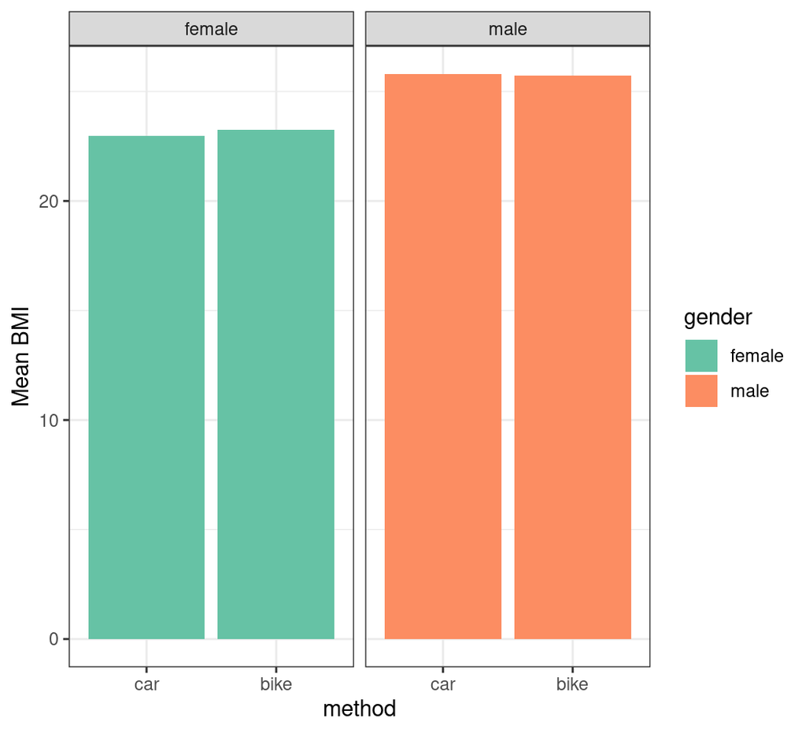

```r
transport |>
  summarise(
    mn_bmi = mean(BMI), sd_bmi = sd(BMI),
    .by = c(method, gender)
  ) |>
  ggplot(aes(method, mn_bmi, fill = gender)) +
  geom_col() +
  facet_wrap(~gender) +
  labs(y = "Mean BMI") +
  scale_fill_brewer(palette = "Set2")
```

## Adding Error Bars

- We add error bars using `geom_errorbar()`

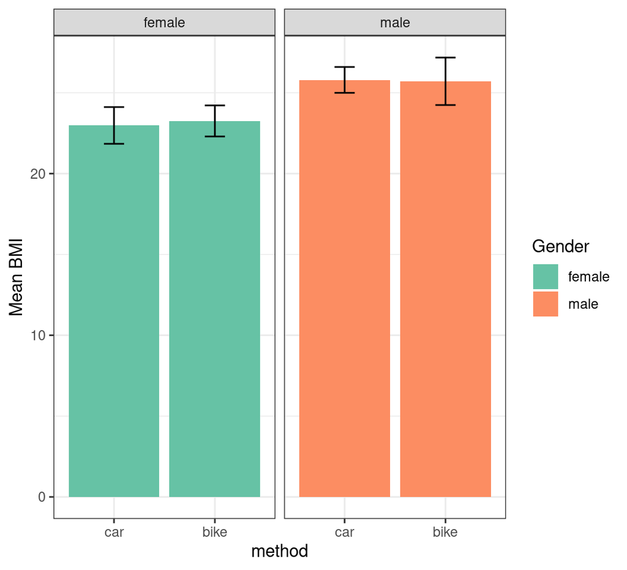

```r
transport |>
  summarise(
    across(BMI, .fns = c(mn = mean, sd = sd)),
    .by = c(method, gender)
  ) |>
  ggplot(aes(method, BMI_mn, fill = gender)) +
  geom_col() +
  geom_errorbar(
    aes(
      ymin = BMI_mn - BMI_sd,
      ymax = BMI_mn + BMI_sd
    ),
    width = 0.2
  ) +
  facet_wrap(~gender) +
  labs(y = "Mean BMI", fill = "Gender") +
  scale_fill_brewer(palette = "Set2")
```

## Modifying Axes

- That space at the bottom of the y-axis bother me
- By default axes expand the data by ~5% of the range
- We can control the expansion
- Using multiplicative scaling (continuous data)
- Using Additive Scaling (discrete data)
- The relevant function is called `expansion()`
- Is passed to the `expand` argument inside `scale_x/y_*()`

## Modifying Axes

- We also label them using the `name` argument

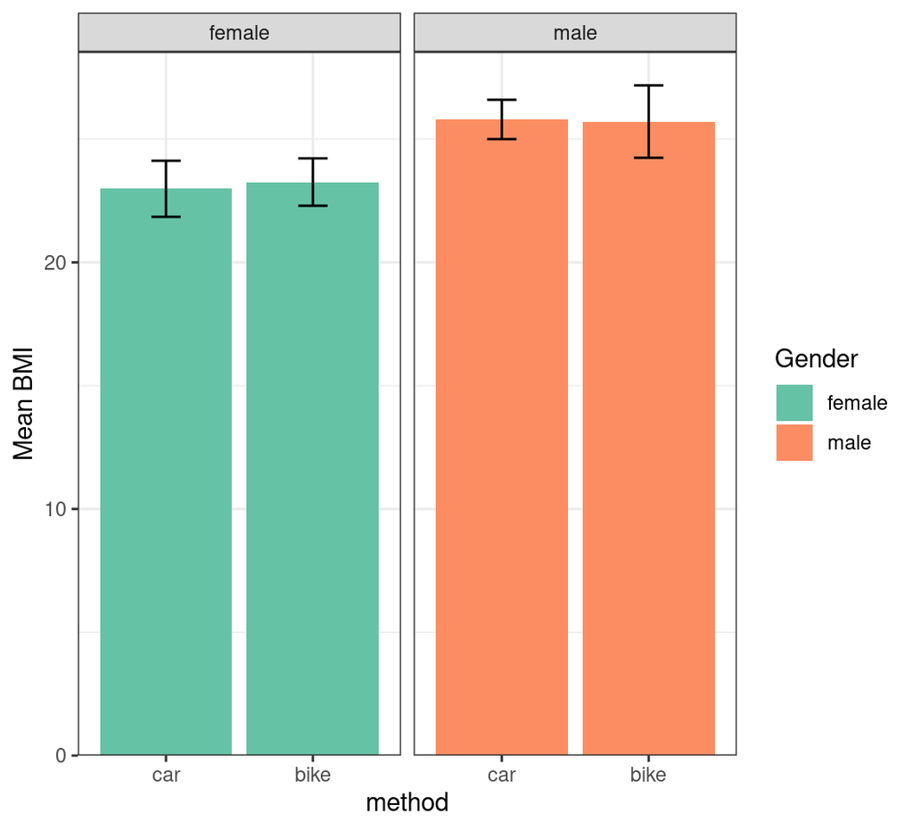

```r
transport |>
  summarise(
    across(BMI, .fns = c(mn = mean, sd = sd)),
    .by = c(method, gender)
  ) |>
  ggplot(aes(method, BMI_mn, fill = gender)) +
  geom_col(position = "dodge") +
  geom_errorbar(
    aes(
      ymin = BMI_mn - BMI_sd,
      ymax = BMI_mn + BMI_sd
    ),
    width = 0.2
  ) +
  facet_wrap(~gender) +
  scale_fill_brewer(
    palette = "Set2", name = "Gender"
  ) +
  scale_y_continuous(
    expand = expansion(c(0, 0.05)),
    name = "Mean BMI"
  )
```

## DIY Time

- Load the RT_PCR data from yesterday

```r
library(readxl)
pcr <- read_excel("data/RealTimeData.xlsx") |>
  setNames(c("Sample", "SLAM", "GAPDH"))
```

- This contains the Ct values for SLAM + GAPDH (HK)
  - Timepoints are 24, 72 and 120h
  - Treatments are Control + Infected

### The Challenge

- Put Control + Infected on the x-axis
- Make a boxplot showing Ct values for SLAM
- Facet by timepoint keeping the order correct
- *Bonus* Taking dCt as SLAM - GAPDH, repeat for dCt

# Using Tidyr

## Splitting Columns

- The first colunm pf `pcr` has a few issues
  - Should fix using `mutate` first

. . .

- One possible way is as below

```r
pcr |>
  mutate(
    Sample = str_replace(Sample, "(C|F)([^ ])", "\\1 \\2") |>
      str_replace("[Hh]$", "hr")
  )
```

*Can you understand this code?*

- C or F without a space has a space inserted
- Replace Upper/Lower case H with lower case hr

## Splitting Columns

- Now we’ve put a space between treatment and timepoint
  - `separate()` will split columns on any character
  - Uses `"[^[:alnum:]]+"` as the default pattern
  - 1 or more consecutive non-alphanumeric characters

```r
pcr |>
  mutate(
    Sample = str_replace(Sample, "(C|F)([^ ])", "\\1 \\2") |>
      str_replace("[Hh]$", "hr")
  ) |>
  mutate(rep = seq_len(n()), .by = Sample) |>
  separate(Sample, into = c("treat", "timepoint"))
```

## Splitting Columns

- Now we can add a column for each replicate
- Also modify the treatment column

```r
pcr |>
  mutate(
    Sample = str_replace(Sample, "(C|F)([^ ])", "\\1 \\2") |>
      str_replace("[Hh]$", "hr")
  ) |>
  mutate(rep = seq_len(n()), .by = Sample) |>
  separate(Sample, into = c("treat", "timepoint"))  |>
  mutate(
    treat = ifelse(treat == "C", "Control", "Infected"),
    timepoint = fct_inorder(timepoint)
  )
```

## Splitting Columns

- We should make this our default object on loading

```r
pcr <- read_excel("data/RealTimeData.xlsx") |>
  setNames(c("Sample", "SLAM", "GAPDH")) |>
  mutate(
    Sample = str_replace(Sample, "(C|F)([^ ])", "\\1 \\2") |>
      str_replace("[Hh]$", "hr")
  ) |>
  mutate(rep = seq_len(n()), .by = Sample) |>
  separate(Sample, into = c("treat", "timepoint"))  |>
  mutate(
    treat = ifelse(treat == "C", "Control", "Infected"),
    timepoint = fct_inorder(timepoint)
  )
```

## `pivot_longer()`

- If we wish to put both GAPDH and SLAM values into 1 column

```r
pcr |>
  pivot_longer(
    cols = all_of(c("SLAM", "GAPDH")), names_to = "gene", values_to = "Ct"
  )
```

## `pivot_longer()`

- Now we can plot each gene by timepoint and treatment
  - Faceting by gene

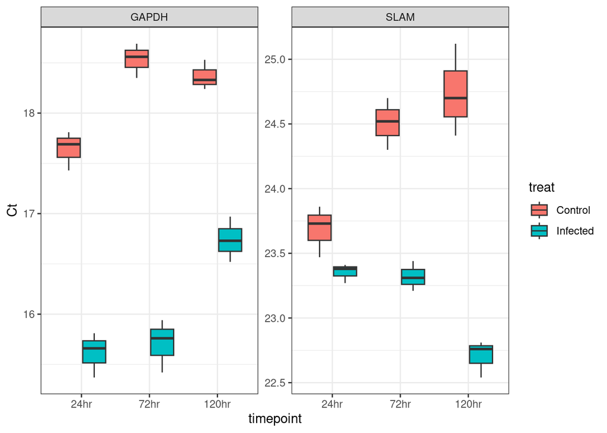

```r
pcr |>
  pivot_longer(
    cols = all_of(c("SLAM", "GAPDH")), names_to = "gene", values_to = "Ct"
  ) |>
  ggplot(aes(timepoint, Ct, fill = treat)) +
  geom_boxplot() +
  facet_wrap(~gene, scales = "free_y")
```

## `pivot_wider()`

- The reverse operation is `pivot_wider()`
- Care is needed with irrelevant columns
  - Manually providing the `id_cols` sets the columns to ‘anchor’ the data

```r
pcr |>
  mutate(dCt = SLAM - GAPDH) |>
  pivot_wider(
    names_from = "rep", values_from = "dCt",
    id_cols = starts_with("t"), names_prefix = "rep"
  )
```

# Themes

## Using Themes

- The overall plot appearance can be set using `theme()`
- A bit overwhelming, but very customisable
- Let’s save our existing plot a `p`
- Can be drawn again at anytime by entering `p`
- Can still be modified on *on-the-fly*

```r
p <- pcr |>
  mutate(dCt = SLAM - GAPDH) |>
  ggplot(aes(treat, dCt, fill = treat)) +
  geom_boxplot() +
  facet_wrap(~timepoint)
```

## Using Themes

- If we try to add a title, it’s aligned left

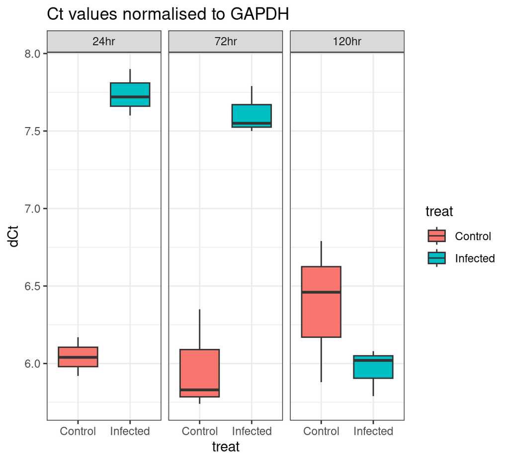

```r
p + ggtitle("Ct values normalised to GAPDH")
```

## Using Themes

- Most `theme()` elements have their own modification functions
- text: `element_text()`
- lines: `element_line()`
- rectangles: `element_rect()`

. . .

- All can be removed using `element_blank`

. . .

- The plot title needs `element_text()`

## Using Themes

- `hjust` controls the horizontal adjustment
- `hjust = 0.5` is centre-aligned

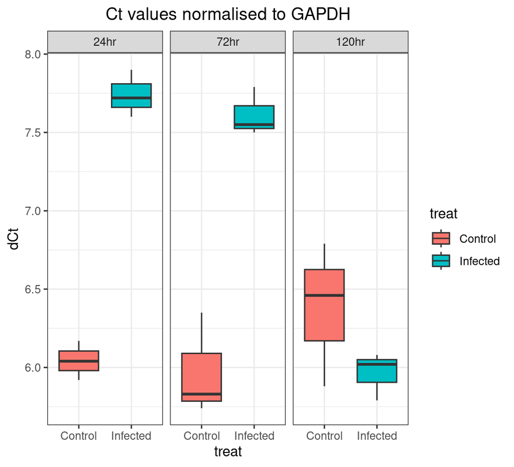

```r
p +
  ggtitle("Ct values normalised to GAPDH") +
  theme(plot.title = element_text(hjust = 0.5))
```

## Using Themes

- We can resize all primary text

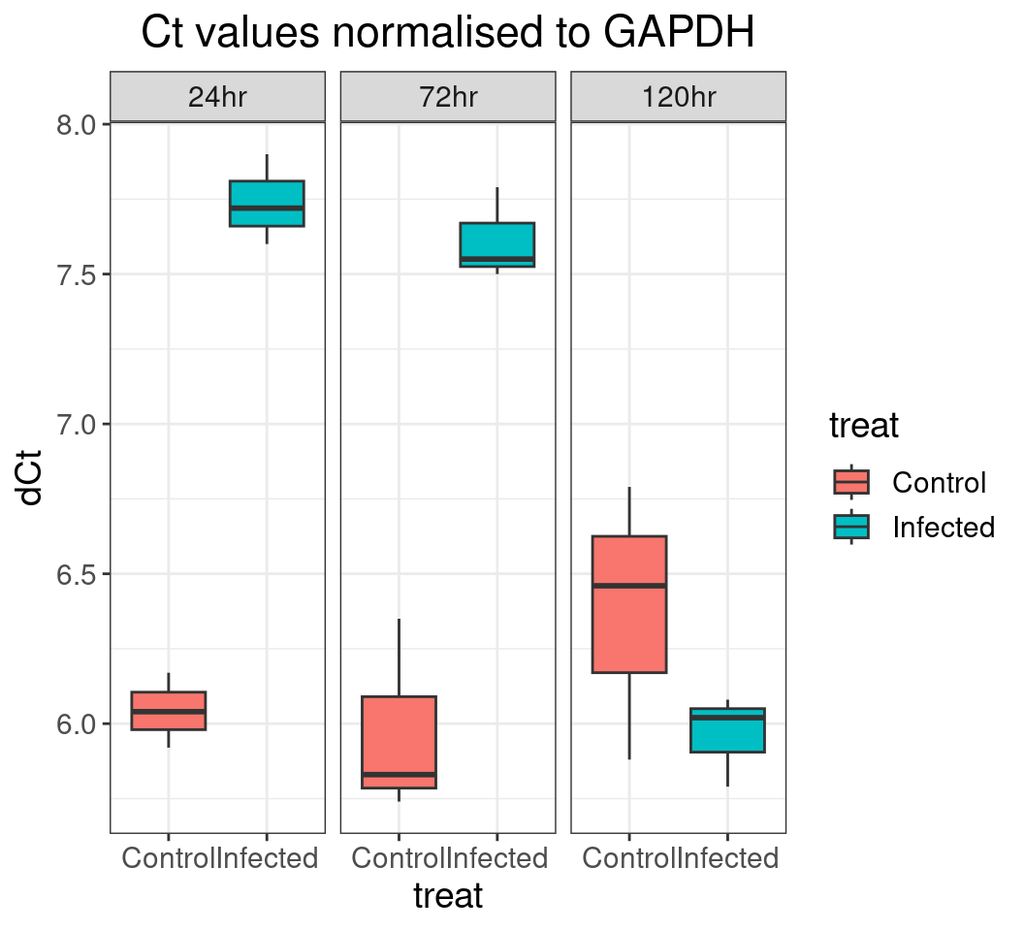

```r
p +
  ggtitle("Ct values normalised to GAPDH") +
  theme(
    text = element_text(size = 14),
    plot.title = element_text(hjust = 0.5)
  )
```

## Using Themes

- Control legend position
- Doesn’t need an `element_*()` function

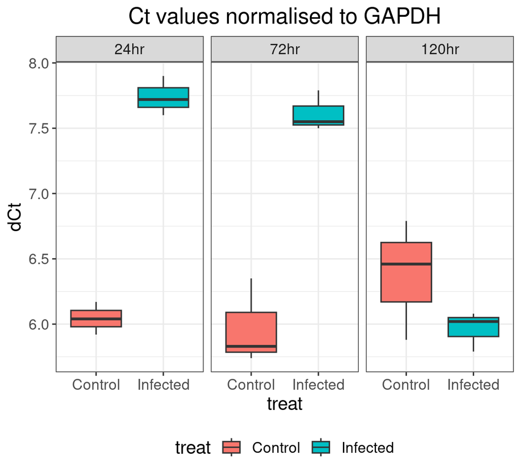

```r
p +
  ggtitle("Ct values normalised to GAPDH") +
  theme(
    text = element_text(size = 14),
    plot.title = element_text(hjust = 0.5),
    legend.position = "bottom"
  )
```

## Using Themes

- Hide the background grid & rotates x-axis text

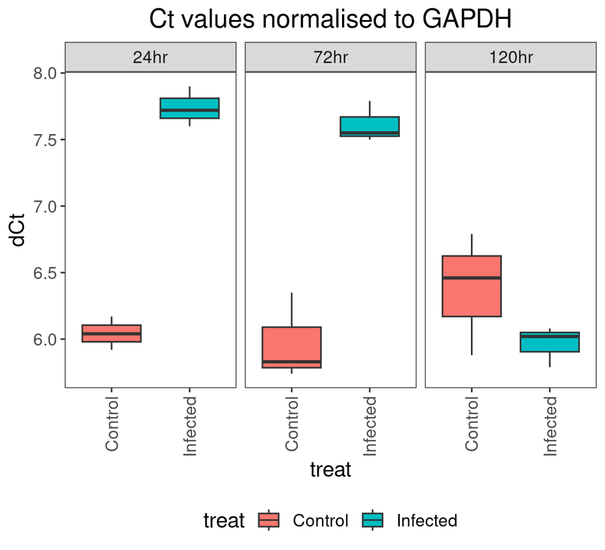

```r
p +
  ggtitle("Ct values normalised to GAPDH") +
  theme(
    text = element_text(size = 14),
    plot.title = element_text(hjust = 0.5),
    legend.position = "bottom",
    panel.grid = element_blank(),
    axis.text.x = element_text(
      angle = 90, vjust = 0.5, hjust = 1
    )
  )
```

## Exporting Plots

- Making plots in `R` is nice  
  $\implies$ *How do we get them into our paper??!!!*

. . .

- `ggsave()` will save the last plot
- The file extension will determine the format
- Can be `png`, `jpg`, `pdf`, `svg`, `tiff` etc
- `width` & `height` default to inches but can be changed

. . .

- Getting font sizes right can be infuriating
- Always add the save after you create the plot
- Open immediately and check the font sizes

## Closing Comments

- Can now (hopefully) make the figures for our next paper
- `ggplot2` is very powerful $\implies$ takes a long time to master
- Getting data structured correctly is an important part

. . .

- Note that once we loaded data $\implies$ never modified

. . .

- We saved four objects
- `transport`, `cols`, `pcr` and `p`
- The last was only to fit the code on slides

. . .

- This keeps a clean workspace
- No need for `pcr`, `pcr1`, `pcr_mod` etc
- Very beneficial for reproducibility